# Distribuição de probabilidades

## Variáveis aleatórias (v.a)

### **Introdução**

- **Variável aleatória unidimensional** é toda função que atribui um único número real, a cada sucesso elemental do espaço amostral.
- Aos possíveis valores de uma v.a se associam probabilidades de ocorrência.

## Classificação das Variáveis aleatórias (v.a)

- **v.a discreta**: é aquela que pode tomar um único número finito ou infinito numerável de valores (não pode existir nenhum valor intermediário).
- Estes valores correspondem a experimentos nos quais um mesmo resultado pode ocorrer várias vezes, e devido a isto, existe o interesse em contá-los.
- **v.a. continua**: pode tomar valores numéricos dentro de um intervalo de modo que entre qualquer dos extremos do intervalo sempre existe outro possível valor.

## Distribuições de probabilidade

- Uma distribuição de probabilidade descreve o comportamento aleatório de um fenômeno dependente do acaso.
- As distribuições de probabilidade podem ser **discretas** ou **contínuas**.

## Função de massa de probabilidade

- Seja X uma v. a. discreta que toma os valores x1, …, xn, já ordenados.
- Se chama função de massa de probabilidade a função que associa a cada xi sua respectiva probabilidade.

## Função de distribuição de uma variável aleatória

- Esta função associa a cada número real a probabilidade de que a variável tome valores menores ou iguais a este número.

## Funções básicas de R no cálculo de distribuições de probabilidades

Existem quatro funções básicas de R que permitem determinar, respectivamente:

- os valores da função de distribuição;
- a função de massa ou densidade (segundo se trate de uma distribuição discreta ou contínua);
- os quantis;
- números aleatórios de determinados modelos probabilísticos.

## Funções básicas de R no cálculo de distribuições de probabilidades

Em concreto se trata das funções:

- p*distribu* (x, par) com a qual calculamos o valor da função de distribuição do modelo *distribu* no ponto x. Isto é, F (x), sendo F a função de distribuição de *distribu*.
- d*distribu* (x, par) com a qual calculamos o valor da função de massa ou densidade da distribuição *distribu* no ponto x.
- q*distribu* (x, par) com a qual podemos calcular o p-quantil da distribuição *distribu*. Isto é, (1/F)(p), sendo F a função de distribuição de *distribu*.
- r*distribu* (n, par) mediante a que podemos conseguir n valores obtidos ao acaso segundo o modelo *distribu*.

## Funções básicas de R no cálculo de distribuições de probabilidades

- O argumento **par** indica o local onde devemos incluir o parâmetro ou parâmetros da distribuição considerada.
- De modo que, se desejamos obter por exemplo, o valor da função de distribuição da normal N(1,2) no ponto x=1,5, executaremos: pnorm (1.5, 1,2).

```r
pnorm (1.5, 1,2)
```

```
## [1] 0.5987063
```

## **Modelos unidimensionais contínuos**

### **Distribuição normal**

- Compreender o tipo de distribuição dos dados é importante em estatística paramétrica.

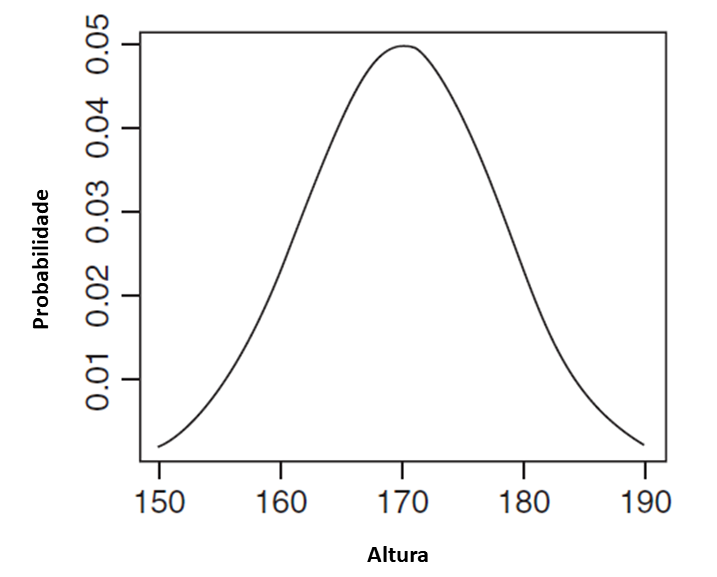

## **Distribuição normal**

- A forma de sino de Gauss depende dos parâmetros: média (μ) e desvio padrão (σ).
- A média indica a posição do sino (centralização);
- O desvio padrão (σ) será o parâmetro de dispersão.
- Quanto menor seja esta dispersão, maior quantidade de massa de probabilidade haverá concentrada perto da média
- Quanto maior seja esta dispersão, o sino sera mais achatado.

## **Distribuição normal**

Para conhecer as caracteristicas de distribuição normal em R:

- pnorm (x, a, b): função de distribuição no ponto \(x\) da normal (a, b).
- dnorm (x, a, b): função de densidade no ponto \(x\) da normal (a, b).
- qnorm (p, a, b): quantil de ordem \(p\) da normal (a, b).
- rnorm (n, a, b): amostra aleatória de tamanho \(n\) da normal (a, b).

## **Distribuição normal**

Exemplo: Vamos supor que foram medidas 100 pessoas.  
A média de altura foi 170 cm e o desvio padrão foi de 8 cm.  
Podemos perguntar tres tipos de questões sobre dados como estes:

- Qual é a probabilidade de selecionarmos por acaso um indivíduo que seja:
1. Menor que uma determinada altura?
2. Mais alto que uma determinada altura?
3. Que tenha altura intermediária entre uma altura especificada e outra?

A área embaixo da totalidade da curva é 1; todos tem uma altura entre menos infinito e mais infinito.

1. A probabilidade de que uma pessoa, selecionada ao acaso deste grupo, seja menor que 160 cm.

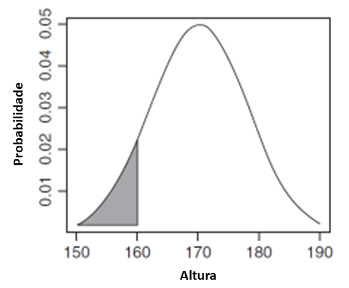

**Nos precisamos converter esta altura em um valor z**.

Isto significa que é necessário converter 160 cm em quanto se desvia da média, o que pode ser feito com o seguinte cálculo:

z = (160 - 170)/8 = -1.25

Agora temos que encontrar a probabilidade do valor da “standard normal” usando este valor de - 1.25 ou menor.  
Este é o valor embaixo da área da esquerda da função de densidade.

A função que precisamos para isso é a pnorm e o nosso z valor.

```r
pnorm(-1.25)
```

```
## [1] 0.1056498
```

Resposta da primeira pergunta: a probabilidade de que uma pessoa, selecionada ao acaso deste grupo, seja menor que 160 cm é de 10,5 %.

Qual a probabilidade de selecionar uma pessoa e encontrar que ela é maior de 185 cm?

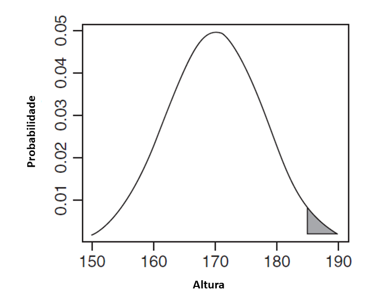

```r
z= (185 - 170)/8
z
```

```
## [1] 1.875
```

Então verificamos qual a probabilidade associada com este valor usando pnorm

```r
 pnorm(1.875)
```

```
## [1] 0.9696036
```

0.9696036 é a probabilidade que alguém seja menor ou igual a 185 cm.

O que necessitamos é trabalhar com o complemento disto:

```r
 1 - pnorm(1.875)
```

```
## [1] 0.03039636
```

Qual é a probabilidade de selecionar uma pessoa e encontrar que ela é maior de 185 cm?

Resposta: 3 %.

Por fim, desejamos saber qual é a probabilidade de selecionar uma pessoa entre 165 cm e 180 cm.

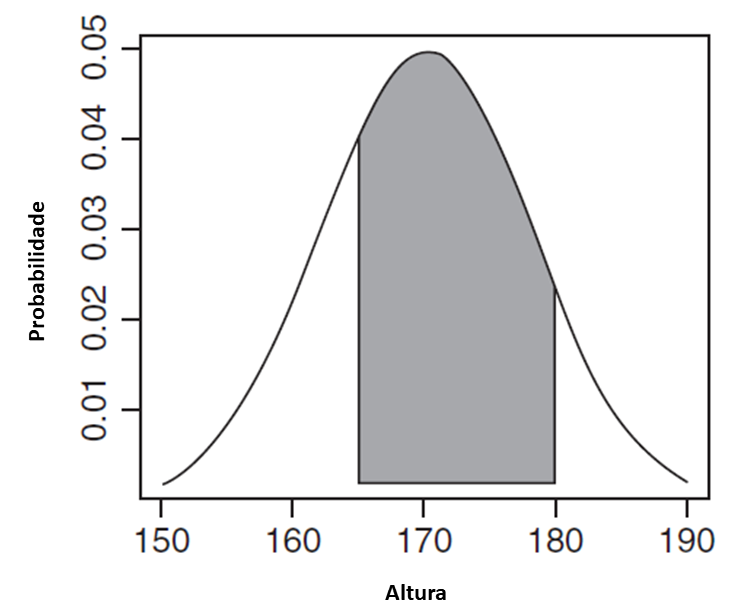

Para isto, teremos que calcular dois z valores.

```r
z1 = (165 - 170)/8
z1
```

```
## [1] -0.625
```

```r
z2 = (180 - 170)/8
z2
```

```
## [1] 1.25
```

O importante aqui é notar que desejamos saber a probabilidade de selecionar uma pessoa entre estes dois z valores, portanto, devemos subtrair a menor probabilidade da maior probabilidade:

```r
pnorm(1.25) - pnorm(-0.625)
```

```
## [1] 0.6283647
```

Portanto, descobrimos que existe a chance de 63 % de selecionar uma pessoa mediana (maior de 165 cm e menor de 180 cm) deste grupo amostra de pessoas com altura média de 170 cm e desvio padrão de 8 cm.

## **O teorema do limite central**

Se você toma amostras repetidas de uma população com variância finita e calcula suas médias, então as médias serão normalmente distribuidas.

## **Gamma**

- A distribuição gamma é útil para descrever processos onde os dados estão deslocados positivamente.
- Um importante uso da distribuição gama é descrever a medição de dados contínuos, os quais não seguem uma distribuição normal.
- É uma distribuição de dois parâmetros, conhecidos como forma (shape) e taxa (rate)
- Casos especiais da distribuição gamma são a **exponencial** e o **qui-quadrado**.

## **Gamma**

- É usada para modelar valores de dados positivos que são assimétricos à direita e maiores que zero.
- É muito utilizada por exemplo, em Meteorologia, para descrever distribuição de precipitação.
- O comando a utilizar em R é gamma.
- pgamma (x, a, b): função de distribuição em \(x\) da gamma (a,b).
- dgamma (x, a, b): função de densidade em \(x\) da gamma (a, b).
- qgamma (p, a, b): quantil de ordem \(p\) da gamma (a, b)
- rgamma (n, a, b): amostra aleatória de tamanho \(n\) da gamma (a, b)

## **Modelos unidimensionais associados a distribuições normais**

### **Distribuição** \(\chi^2\) **de Pearson**

- pchisq (x, n): função de distribuição em \(x\) da Chi-quadrado com \(n\) grados de liberdade.
- dchisq (x, n): função de densidade em \(x\) da Chi-quadrado com \(n\) graus de liberdade.
- qchisq (p, n): quantil de ordem \(p\) da Chi-quadrado com \(n\) grados de liberdade.
- rchisq (m, n): amostra aleatória de tamanho \(m\) da Chi-quadrado com \(n\) graus de liberdade.

A distribuição X² de Pearson se aproxima de uma normal a medida que N aumenta.

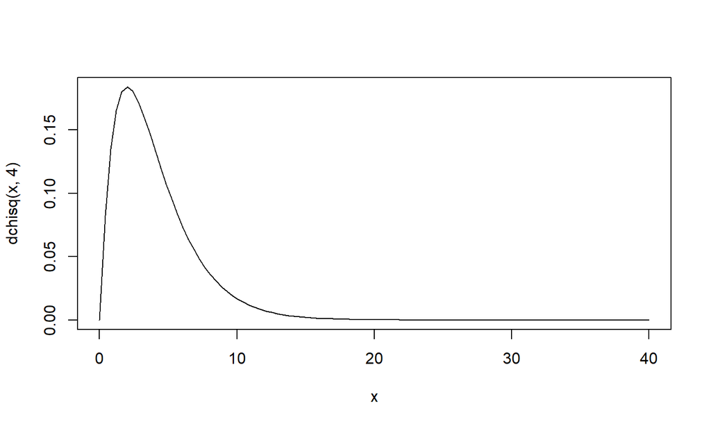

```r
x<-seq(0,40,len=100)
plot(x,dchisq(x,4),type="l",col=1)
```

## **Distribuição** \(\chi^2\) **de Pearson**

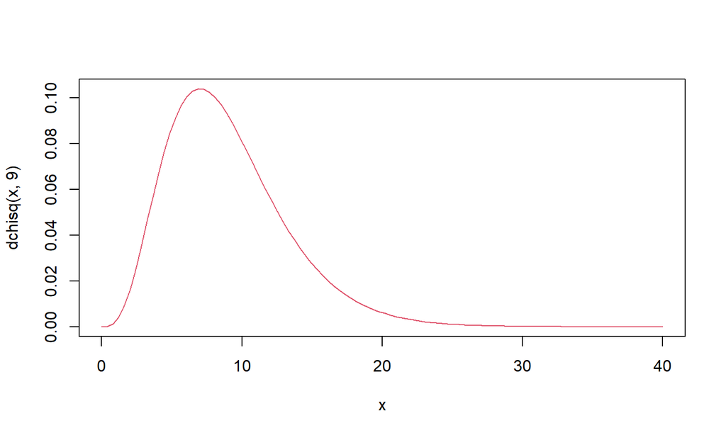

```r
x<-seq(0,40,len=100)
plot(x,dchisq(x,9),type="l",col=2)
```

## **Distribuição** \(\chi^2\) **de Pearson**

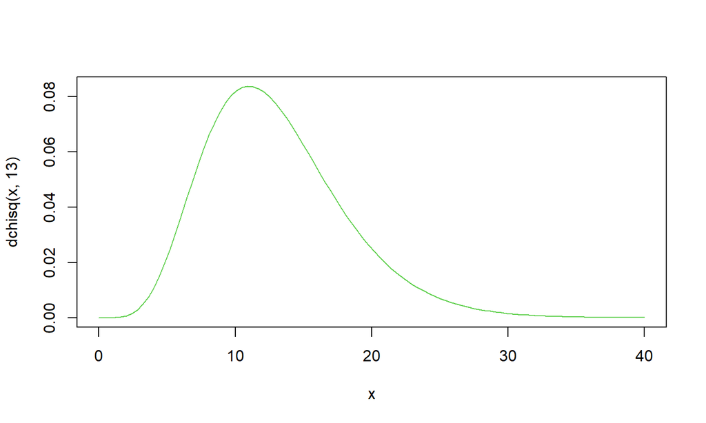

```r
x<-seq(0,40,len=100)
plot(x,dchisq(x,13),type="l",col=3)
```

## **Distribuição *t* de Student**

A distribuição t de Student tem propriedades parecidas a N(0,1):

- É de média zero e simétrica;
- É algo mais dispersa que a normal, porém a variância decresce até 1 quando o número dos graus de liberdade aumenta;
- Para um número alto de graus de libertade se pode aproximar a distribuição de Student pela normal.

## **Distribuição *t* de Student**

O comando a utilizar em R é t.

- pt (x,n): função de distribuição em \(x\) da t-Student com \(n\) graus de liberdade.
- dt (x, n): função de densidade em \(x\) da t-Student com \(n\) graus de liberdade.
- qt (x, n): quantil de ordem \(p\) da t-Student com \(n\) graus de liberdade.
- rt (x, n): amostra aleatória de tamanho \(m\) a t-Student com n graus de liberdade.

## Exemplo

A distribuição t de Student se aproxima em uma N(0,1) quando \(n\) aumenta.

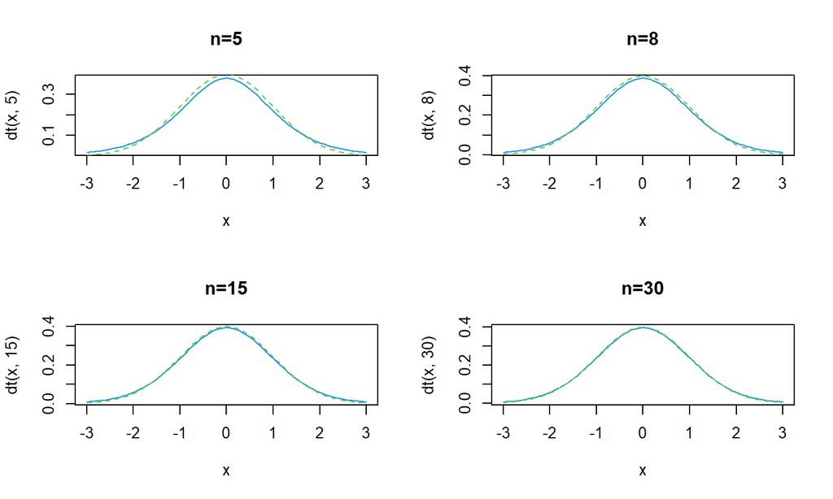

A figura gerada estava representando a densidade da t de Student com n = 5, 8, 15 e 30 graus de liberdade e sobrepondo em cada caso, a densidade da normal padrão.

## **Distribuição F de Snedecor**

- A distribuição F de Snedecor é frequentemente utilizada na inferência estatística para análise da variância.
- Exemplo: pode ser usada em teste de hipóteses para determinar se as variâncias de duas populações são iguais ou não.
- O estatístico de F calcula-se dividindo a variância maior pela variância menor.

## **Principais características**

- Cada par de graus de liberdade da origem a uma distribuição F diferente;
- A distribuição F depende de dois parâmetros. O primeiro (v1) é o grau de liberdade do numerador e o segundo (v2) do denominador;
- A variável aleatória F é não-negativa, e a distribuição é assimétrica à direita;

O comando em R é **f**. Assim:

- pf (x, n1, n2) # função de distribuição em \(x\) da F (n1, n2)
- df (x, n1, n2) # função de densidade em \(x\) da F (n1, n2)
- qf (p, n1, n2) # quantil de ordem \(p\) da F (n1, n2)
- rf (n, n1, n2) # amostra aleatória de tamanho \(n\) da F (n1, n2)

## Modelos unidimensionais discretos

### Distribuição binomial

- É uma distribuição discreta que modela o número de eventos em um número fixo de ensaios.
- Cada ensaio tem dois resultados possíveis e evento é o resultado de interesse de um ensaio.
- Pode ser usada para descrever um processo onde você estiver interessado na ocorrência de um evento e não em sua magnitude.
- É frequentemente usada no controle de qualidade, em pesquisas de opinião pública, em pesquisas médicas e em seguros.

## Distribuição binomial

O número de eventos (X) em n ensaios segue uma distribuição binomial, se forem atendidas as seguintes condições:

- O número de ensaios é fixo.
- Cada ensaio é independente dos outros ensaios.
- Cada ensaio tem um de dois resultados: evento ou não-evento.
- A probabilidade de um evento é a mesma para cada ensaio.

## Distribuição binomial

O comando a utilizar no R é *binom*.

- pbinom (x, n, p): valor da função de distribuição no \(x\) da binomial (n, p).
- dbinom (x, n, p): valor da função de massa no \(x\) da binomial (n, p).
- qbinom (q, n, p): quantil de ordem \(q\) da binomial (n, p).
- rbinom (m, n, p): amostra aleatória de tamanho \(m\) da binomial (n, p)

## Exemplos

O número de itens defeituosos (X) segue uma distribuição binomial com n = 25 e p = 0,02.

```r
dbinom (3, 25, 0.02)
```

```
## [1] 0.01179754
```

## Exemplos

1. Se queremos representar a função de massa de uma distribuição binomial B (5, 0,33) executariamos a seguinte sequência para obter o gráfico.
- Destacamos que no argumento type da função plot foi utilizada a opção **h** para obter um gráfico tipo histograma.

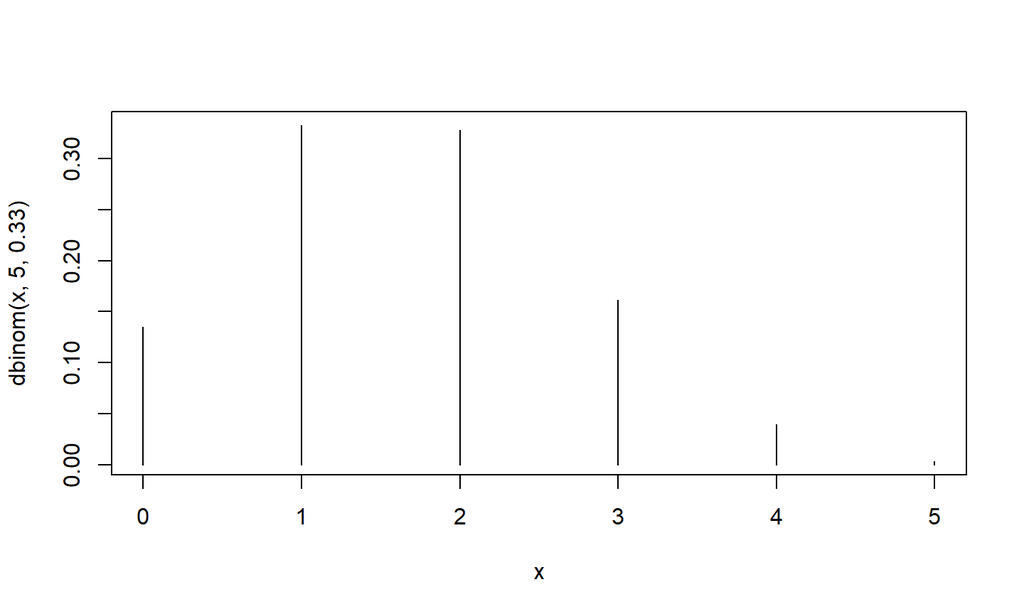

```r
x <- seq(0,5,len=6)
plot(x,dbinom(x,5,0.33), type="h")
```

## Exemplos

Se desejamos representar a função de distribuição de B (5, 0.33) executariamos a seguinte sequência:

- **s** significa o argumento type da função plot.

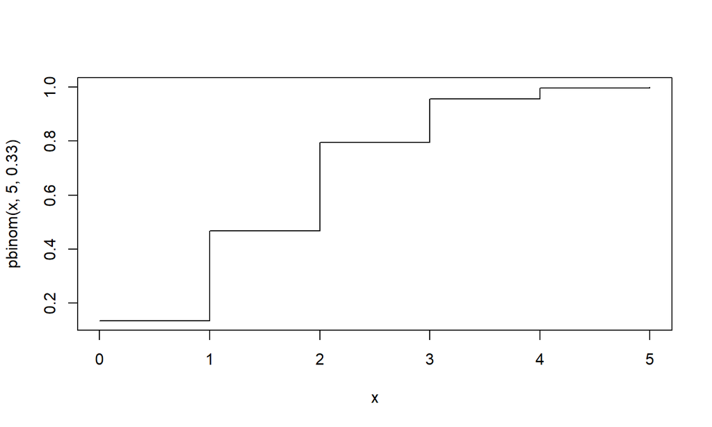

```r
x <- seq(0,5,len=6)
plot(x,pbinom(x,5,0.33), type="s")
```

## Distribuição de Poisson

- É uma distribuição de probabilidade de uma variável aleatória discreta;
- Expressa a probabilidade de uma série de eventos ocorram independentemente de quando ocorreu o último evento.

## Distribuição de Poisson

- A distribuição de Poisson é especificada por um parâmetro: lambda (λ).
- Este parâmetro é igual à média e à variância. Conforme lambda aumenta para valores suficientemente grandes, a distribuição normal pode ser usada para aproximar a distribuição de Poisson.
- A distribuição de Poisson pode ser usada para descrever o número de vezes que um evento ocorre em um espaço de observação finito.

## Distribuição de Poisson

- Por exemplo, uma distribuição de Poisson pode descrever o número de chamadas por hora para uma central de atendimento.

Uma variável segue uma distribuição de Poisson se as seguintes condições forem atendidas:

- Os dados são contagens de eventos (inteiros não-negativos com nenhum limite superior).
- Todos os eventos são independentes.
- A taxa média não muda sobre o período de interesse.

## Distribuição de Poisson

O comando a utilizar em R é pois.

- ppois (x, a): valor da função de distribuição de \(x\) de Poisson (a).
- dpois (x, a): valor da função de massa de \(x\) da Poisson (a).
- qpois (x, a): quantil de ordem \(p\) da Poisson (a).
- rpois (n, a): amostra aleatória de tamanho \(n\) da Poisson (a).

## O que é taxa de ocorrência?

A taxa de ocorrência é igual à média (λ) dividida pela dimensão do seu espaço de observação.

- É útil para comparar contagens de Poisson coletadas em diferentes espaços de observação.

## Exemplo 1

A central **A** recebe 50 chamadas telefônicas em 5 horas, e a central **B** recebe 80 chamadas em 10 horas.

Você não pode comparar diretamente esses valores porque seus espaços de observação são diferentes.

Você deve calcular a taxa de ocorrência para comparar essas contagens.

A taxa para a central telefônica A é (50 chamadas / 5 horas) = 10 chamadas/hora. A taxa da central telefônica B é (80 chamadas / 10 horas) = 8 chamadas/hora.

## Exemplo 2

- Em uma editorial se assume que todo livro de 250 páginas tem uma media de 50 erros.
- Encontre a probabilidade de que em uma página qualquer não se encontrem erros.
- O objetivo é calcular P (X = 0); para obter esta probabilidade se usa a seguinte instrução.

```r
dpois(x=0, lambda=0.2)
```

```
## [1] 0.8187308
```

Resposta: a probabilidade de P (X = 0) é de 0.8187

## Distribuição Binomial Negativa

- A distribuição binomial negativa é uma distribuição discreta que modela o número de ensaios que são necessários para produzir um número de eventos específico.
- Cada ensaio tem dois resultados possíveis. Um evento é o resultado de interesse de um ensaio.

## Distribuição Binomial Negativa

O comando a utilizar em R é n*binom*.

- pnbinom (x, n, p): função de distribuição de \(x\) da binomial negativa (n, p).
- dnbinom (x, n, p): função de massa em \(x\) da binomial negativa (n, p).
- qnbinom (q, n, p): quantil de ordem \(q\) da binomial negativa (n, p).
- rnbinom (n, n, p): amostra aleatória de tamanho \(n\) da binomial negativa (n, p).

## Exemplo 1 de Binomial Negativa

- Uma família deseja ter filhos até conseguir 2 meninas, a probabilidade individual de obter uma menina é 0.5 e se supõe que todos os nascimentos são individuais, isto é, somente um bebê.
- Calcular a probabilidade de que se necessitem 4 filhos, isto é, 4 nascimentos para conseguir as duas meninas.
- Neste problema existe uma distribuição binomial negativa com r= 2 meninas, que são os êxitos desejados pela família.
- A variável X representa os fracassos, isto é, os meinos, até que se consigam os êxitos r = 2 desejados.
- Neste caso o que interessa é P (X = 2)
- A instrução para calcular a probabilidade é a seguinte.

```r
dnbinom(2, 2, 0.5)
```

```
## [1] 0.1875
```

## Exemplo 2 de Binomial Negativa

Calcular P (família tenha ao menos 4 filhos)

### P (X ≥ 2) = 1 −[P(X = 0) + P = 1)

```r
1 - sum(dnbinom(0:1, 2, 0.5))
```

```
## [1] 0.5
```

## Referências

- Freddy Hernández; Olga Usuga.2021. **Manual de R**.
  - https://fhernanb.github.io/Manual-de-R/index.html
- Suporte ao minitab [minitab 18]
  - (https://support.minitab.com/pt-br/minitab/18/help-and-how-to/probability-distributions-and-random-data/supporting-topics/distributions/poisson-distribution/)
- Crawley, M.J. **The R book**. Wiley, 2007.
- Pérez, A.G. **Estadística aplicada con R**. Universidad Nacional de Educación a distancia. Editorial Aranzadi, S.A. 2012.